# Chapter 13. Design and Analysis for Epidemiologic Studies

Prof. Donghwan Lee

## Agenda

- Common study designs used in epidemiologic work
- Several measures of effect that are commonly used for categorical data
- Controlling the confounding variables
- Meta-analysis
- Several alternative study designs: Active-control designs/ Cross-over designs
- Methods for handling missing data
- Introduction to longitudinal data analysis

### Study design

- Exposure variable vs Disease variable

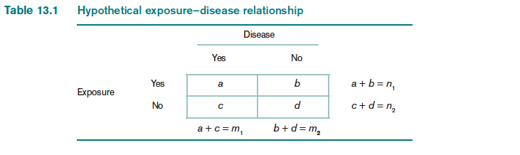

- A **prospective study** is a study in which a group of disease-free individuals is identified at one point in time and are followed over a period of time until some of them develop the disease. The development of disease over time is then related to other variables measured at baseline, generally called exposure variables. The study population in a prospective study is often called a cohort. Thus another name for this type of study is a **cohort study**.
- A prospective study is usually more definitive because the patients’ knowledge of their current health habits is more precise than their (or related individuals’) recall of their past health habits.
- A **retrospective study** is a study in which two groups of individuals are initially identified: (1) a group that has the disease under study (the cases) and (2) a group that does not have the disease under study (the controls). An attempt is then made to relate their prior health habits to their current disease status. This type of study is also sometimes called a **case–control** study.

: Cheap but

1. Selection bias: it is much more difficult to obtain a representative sample of people who already have the disease in question.
2. Recall bias: the diseased individuals, if still alive, or their surrogates may tend to give biased answers about prior health habits if they believe there is a relationship between these prior health habits and the disease
- A **cross-sectional study** is one in which a study population is ascertained at a single point in time. All participants in the study population are asked about their current disease status and their current or past exposure status. This type of study is sometimes called a prevalence study because the prevalence of disease at one point in time is compared between exposed and unexposed individuals. This contrasts with a **prospective study**, in which one is interested in the incidence rather than the prevalence of disease.

### Measures of effect for categorical data

- $p_1:$ probability of developing disease for exposed individuals
- $p_2:$ probability of developing disease for unexposed individuals
- Risk difference (RD) : $p_1 - p_2$
- Risk ratio (relative risk; RR) : $p_1/p_2$

**Risk difference**

$$\hat p_1 - \hat p_2 \sim N(p_1-p_2, \frac{p_1q_1}{n_1} + \frac{p_2q_2}{n_2})$$

CI of RD (without continuity correction):
$$\hat p_1 - \hat p_2 \pm z_{1-\alpha/2}\sqrt{\frac{\hat p_1 \hat q_1}{n_1} + \frac{\hat p_2 \hat q_2}{n_2}}$$

**Risk Ratio**

$$\hat RR = \hat p_1 / \hat p_2$$
$$Var[log \hat RR] = Var[\log \hat p_1 ] + Var[\log \hat p_2 ] \approx \frac{\hat q_1 }{\hat p_1 n_1}
+\frac{\hat q_2 }{\hat p_2 n_2} =
\frac{b }{a n_1}
+\frac{d }{c n_2}$$

NOTE: Delta method

The variance of a function of a r.v. $f(X)$ is approximated by
$$Var(f(X)) \approx [f'(X)]^2Var(X)$$

**Odds ratio**

$$OR = \frac{p_1/q_1}{p_2/q_2}$$

- The disease-odds ratio is the odds in favor of disease for the exposed group divided by the odds in favor of disease for the unexposed group.
- The exposure-odds ratio is the odds in favor of being exposed for diseased subjects divided by the odds in favor of being exposed for nondiseased subjects.

$\Rightarrow$ SAME!(by Bayes’ rule)

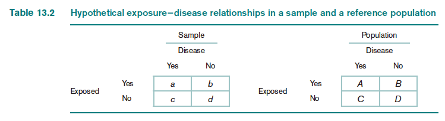

In a case–control study, we assume that a random fraction $f_1$ of subjects with disease and a random fraction $f_2$ of subjects without disease in the reference population are included in our study sample.

$$a=f_1A; c=f_1C; b=f_2B; d=f_2D$$
$$\hat RR = \frac{a/(a+b)}{c/(c+d)}= \frac{A/(f_1A+f_2B)}{C/(f_1C+f_2D)}
\neq \frac{A/(A+B)}{C/(C+D)} = RR$$

$$\hat OR = \frac{ad}{bc} = \frac{f_1Af_2D}{f_2Bf_1C} = \frac{AD}{BC} = OR$$

If the disease under study is rare, then the disease-odds ratio is approximately the same as the RR.

**Interval Estimation of OR**

Woolf method: by using Delta method,
$$Var(\log \hat OR) \approx \frac{1}{a} + \frac{1}{b}+\frac{1}{c}+\frac{1}{d}$$

### Confounding and Standardization

When looking at the relationship between a disease and an exposure variable, it is often important to control for the effect of some other variable that is associated with both the disease and the exposure variable.

- A **confounding variable** is a variable that is associated with both the disease and the exposure variable. Such a variable must usually be controlled for before looking at a disease–exposure relationship.

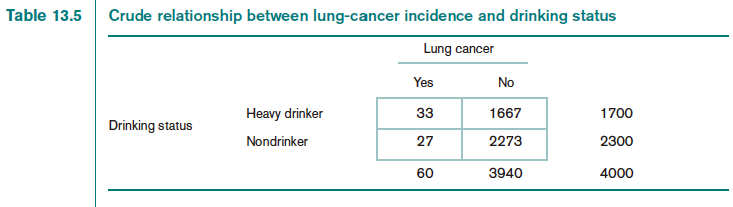

**Crude relationship** (the relationship is presented without any adjustment for possible confounding variables):
$$RR \approx OR = \frac{33*2273}{1667*27} = 1.67$$

**Stratification**:

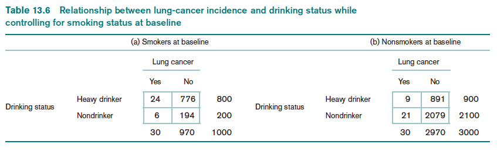

To investigate the relationship between lung-cancer incidence and drinking status, while controlling for smoking status, we can compute separate ORs for Table 13.6a and b. The OR relating lung cancer to drinking status among smokers is $OR=1$ whereas the comparable OR among nonsmokers is $OR=1$. Thus, after controlling for the confounding variable smoking, we find **no relationship** between lung cancer and drinking status.

$\Rightarrow$ Smoking is a positivie confounder.

Positive confounder is (1) is positively related to both exposure and disease, or (2) is negatively related to both exposure and disease After adjusting for a positive confounder, an adjusted RR or OR is lower than the crude RR or OR.

A confounder is said to be in the **causal pathway** between exposure and disease if (1) the exposure is causally related to the confounder and (2) the confounder is causally related to disease.

**Example 13.20** Suppose we are interested in the possible association between obesity and the development of coronary heart disease (CHD). If we examine the crude relationship between obesity and CHD, we usually find that obese people have higher rates of CHD than do people of normal weight. However, obesity is positively related to both hypertension and diabetes. In some studies, once hypertension and/or diabetes is controlled for as a confounder, there is a much weaker relationship or even no relationship between obesity and the development of CHD. Does this mean there is no real association between obesity and CHD?

**Standardization**

The term “age standardized” means the expected disease rates in the exposed and unexposed groups are each based on an age distribution from a standard reference population. If the same standard is used for both the exposed and unexposed groups, then a comparison can be made between the two standardized rates that is not confounded by possible age differences between the two populations.

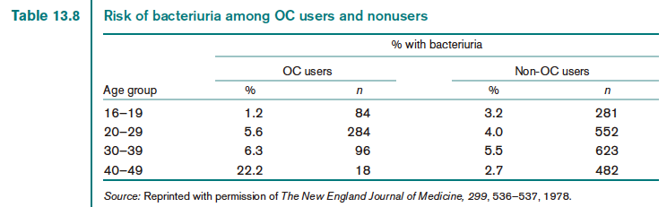

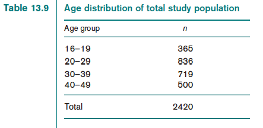

Age-standardized risk of disease among the exposed
$$\hat p_1^* = \sum_i n_i \hat p_{i1}/ \sum_i n_i$$
Standardized RR = $\hat p_1^* / \hat p_2^*$

### Mantel-Haenzel Test

**Example 13.23** A 1985 study identified a group of 518 cancer cases ages 15−59 and a group of 518 age- and sex-matched controls by mail questionnaire [4]. The main purpose of the study was to look at the effect of passive smoking on cancer risk. The study defined passive smoking as exposure to the cigarette smoke of a spouse who smoked at least one cigarette per day for at least 6 months. One potential confounding variable was smoking by the participants themselves (i.e., personal smoking) because personal smoking is related to both cancer risk and spouse smoking. Therefore, it was important to control for personal smoking before looking at the relationship between passive smoking and cancer risk.

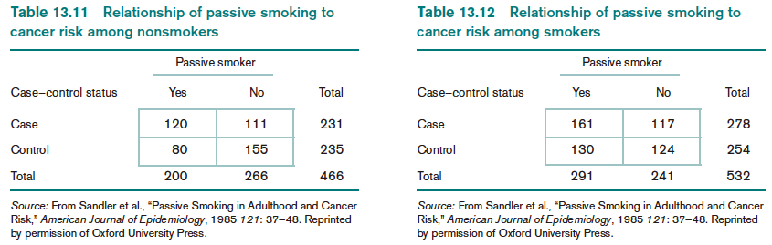

- OR for nonsmokers = 2.1
- OR for smokers = 1.3
- How to combine the results from the two tables to obtain an overall estimated OR and test of significance for the passive-smoking effect?

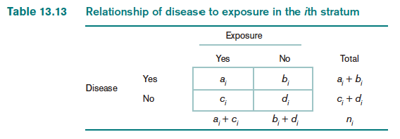

$$X_{MH}^2 = (|O-E|-.5)^2/V \sim \chi^2_1 \text{ under } H_0$$
where $O=\sum_{i=1}^k O_i, E=\sum_{i=1}^k E_i$ and
$$V=\sum_i V_i = \sum_i \frac{(a_i+b_i)(c_i+d_i)(a_i+c_i)(b_i+d_i)}{n_i^2(n_i-1)}$$
- Estimation of the OR for stratified data
$$\hat OR_{MH} = \frac{\sum_i a_id_i/n_i}{ \sum_i b_ic_i/n_i}$$
A two-sided CI for common OR is given by

$$\exp [\log \hat OR_{MH} \pm z_{1-\alpha/2}\sqrt{Var (\log \hat OR_{MH})} ]$$

```r
x1<-matrix(c(120,80,111,155),2,2)
x2<-matrix(c(161,130,117,124),2,2)
x<-array(0,c(2,2,2))
x[,,1]<-x1
x[,,2]<-x2

mantelhaen.test(x)
```

```
##
##  Mantel-Haenszel chi-squared test with continuity correction
##
## data:  x
## Mantel-Haenszel X-squared = 13.942, df = 1, p-value = 0.0001885
## alternative hypothesis: true common odds ratio is not equal to 1
## 95 percent confidence interval:
##  1.263955 2.090024
## sample estimates:
## common odds ratio
##          1.625329
```

One assumption made in the estimation of a common OR in MH-test is that the strength of association is the same in each stratum. If the underlying OR is different in the various strata, then it makes little sense to estimate a common OR.

To test the hypothesis $H_0: OR_1 = ...=OR_k$,

Compute test statistic
$$X_{HOM}^2 = \sum_{i=1}^k w_i (\log \hat OR_i - \overline{\log OR})^2 \sim \chi_{k-1}^2$$
where $w_i = (\frac{1}{a_i}+\frac{1}{b_i}+\frac{1}{c_i}+\frac{1}{d_i})^{-1}$

### Multiple Logistic Regression

$$logit(p)=\log \frac{p}{1-p} = \alpha + \beta_1x_1+...+\beta_k x_k$$
If
$$logit(p_A) = \alpha + \beta_1x_1+...+\beta_j(1)+...+\beta_k x_k$$

$$logit(p_B) = \alpha + \beta_1x_1+...+\beta_j(0)+...+\beta_k x_k$$

$$\frac{p_A/(1-p_A)}{p_B/(1-p_B)} = e^{\beta_j}$$

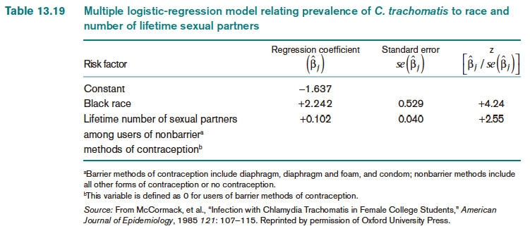

Estimate the odds in favor of infection with C. trachomatis for black women compared with white women after controlling for previous sexual experience, and provide a 95% CI about this estimate.

$$\hat OR = e^{2.242} = 9.4$$

Thus the odds in favor of infection for black women are nine times as great as those for white women after controlling for previous sexual experience.

CI:
$$e^{\hat \beta_j \pm z_{1-\alpha/2}se(\hat\beta_j)}$$

**Relationship between logistic regression and Contingency-table analysis**

In Logistic regression:
$$\log[p/(1-p)] = \alpha + \beta E \Rightarrow OR = e^\beta$$
In 2*2 table:
$$OR = ad/bc$$

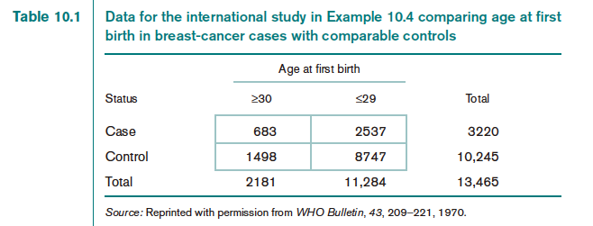

```r
case<-c(683,2537)
total<-c(2181,11284)
AGE30<-c(1,0)
rst<-glm(cbind(case,total-case)~AGE30,family=binomial(link="logit"))
summary(rst)
```

```
##
## Call:
## glm(formula = cbind(case, total - case) ~ AGE30, family = binomial(link = "logit"))
##
## Deviance Residuals:
## [1]  0  0
##
## Coefficients:
##             Estimate Std. Error z value Pr(>|z|)
## (Intercept) -1.23773    0.02255 -54.889   <2e-16 ***
## AGE30        0.45234    0.05138   8.803   <2e-16 ***
## ---
## Signif. codes:  0 '***' 0.001 '**' 0.01 '*' 0.05 '.' 0.1 ' ' 1
##
## (Dispersion parameter for binomial family taken to be 1)
##
##     Null deviance: 7.4604e+01  on 1  degrees of freedom
## Residual deviance: 1.3369e-12  on 0  degrees of freedom
## AIC: 21.411
##
## Number of Fisher Scoring iterations: 2
```

```r
predict(rst,type="link")
```

```
##          1          2
## -0.7853913 -1.2377285
```

```r
predict(rst,type="response")
```

```
##         1         2
## 0.3131591 0.2248316
```

```r
case/total
```

```
## [1] 0.3131591 0.2248316
```

```r
OR<-exp(rst$coef)
OR ## OR
```

```
## (Intercept)       AGE30
##   0.2900423   1.5719819
```

```r
OR.U<-exp(rst$coef +1.96*summary(rst)$coef[,2])
OR.L<-exp(rst$coef -1.96*summary(rst)$coef[,2])
cbind(OR,OR.L,OR.U)
```

```
##                    OR      OR.L     OR.U
## (Intercept) 0.2900423 0.2775023 0.303149
## AGE30       1.5719819 1.4213785 1.738543
```

```r
exp(cbind(coef(rst),confint(rst))) ## Use profile likelihood
```

```
##                           2.5 %    97.5 %
## (Intercept) 0.2900423 0.2774522 0.3030949
## AGE30       1.5719819 1.4208249 1.7379057
```

**Example** Dose-response study (Bliss, 1935)

- Beetles killed after exposure to Carbon disulfide
- Response: dead or alive
- Covariate: $\log_{10}$(dose)

```r
load("Data/RData_logistic.RData")
beetles[1:10,] # ungrouped format
```

```
##        x y
## 1  1.691 1
## 2  1.691 1
## 3  1.691 1
## 4  1.691 1
## 5  1.691 1
## 6  1.691 1
## 7  1.691 0
## 8  1.691 0
## 9  1.691 0
## 10 1.691 0
```

```r
beetles2 # grouped format
```

```
##   logdose  n dead
## 1   1.691 59    6
## 2   1.724 60   13
## 3   1.755 62   18
## 4   1.784 56   28
## 5   1.811 63   52
## 6   1.837 59   53
## 7   1.861 62   61
## 8   1.884 60   60
```

```r
## ungrouped data
fit1<-glm(y~x, data=beetles, family=binomial(link=logit))
summary(fit1)
```

```
##
## Call:
## glm(formula = y ~ x, family = binomial(link = logit), data = beetles)
##
## Deviance Residuals:
##     Min       1Q   Median       3Q      Max
## -2.4946  -0.5979   0.2047   0.4491   2.3765
##
## Coefficients:
##             Estimate Std. Error z value Pr(>|z|)
## (Intercept)  -60.740      5.182  -11.72   <2e-16 ***
## x             34.286      2.913   11.77   <2e-16 ***
## ---
## Signif. codes:  0 '***' 0.001 '**' 0.01 '*' 0.05 '.' 0.1 ' ' 1
##
## (Dispersion parameter for binomial family taken to be 1)
##
##     Null deviance: 645.44  on 480  degrees of freedom
## Residual deviance: 372.35  on 479  degrees of freedom
## AIC: 376.35
##
## Number of Fisher Scoring iterations: 5
```

```r
## grouped data

fit2<-glm(cbind(dead, n-dead)~logdose, data=beetles2, family=binomial(link=logit))
summary(fit2)
```

```
##
## Call:
## glm(formula = cbind(dead, n - dead) ~ logdose, family = binomial(link = logit),
##     data = beetles2)
##
## Deviance Residuals:
##     Min       1Q   Median       3Q      Max
## -1.5878  -0.4085   0.8442   1.2455   1.5860
##
## Coefficients:
##             Estimate Std. Error z value Pr(>|z|)
## (Intercept)  -60.740      5.182  -11.72   <2e-16 ***
## logdose       34.286      2.913   11.77   <2e-16 ***
## ---
## Signif. codes:  0 '***' 0.001 '**' 0.01 '*' 0.05 '.' 0.1 ' ' 1
##
## (Dispersion parameter for binomial family taken to be 1)
##
##     Null deviance: 284.202  on 7  degrees of freedom
## Residual deviance:  11.116  on 6  degrees of freedom
## AIC: 41.314
##
## Number of Fisher Scoring iterations: 4
```

```r
summary(fit2)$cov.unscaled ## Var(betahat)
```

```
##             (Intercept)   logdose
## (Intercept)    26.85178 -15.09108
## logdose       -15.09108   8.48681
```

```r
## Estimates of coef
summary(fit2)$coef
```

```
##              Estimate Std. Error   z value     Pr(>|z|)
## (Intercept) -60.74013   5.181870 -11.72166 9.871561e-32
## logdose      34.28593   2.913213  11.76911 5.631446e-32
```

```r
fit2$coef
```

```
## (Intercept)     logdose
##   -60.74013    34.28593
```

```r
## fitted value
fit2$fitted.value
```

```
##          1          2          3          4          5          6
## 0.05937747 0.16366723 0.36162283 0.60490961 0.79440490 0.90405532
##          7          8
## 0.95546748 0.97925643
```

```r
## P-value for Goodness of fit
1-pchisq(deviance(fit2), df.residual(fit2))
```

```
## [1] 0.08486944
```

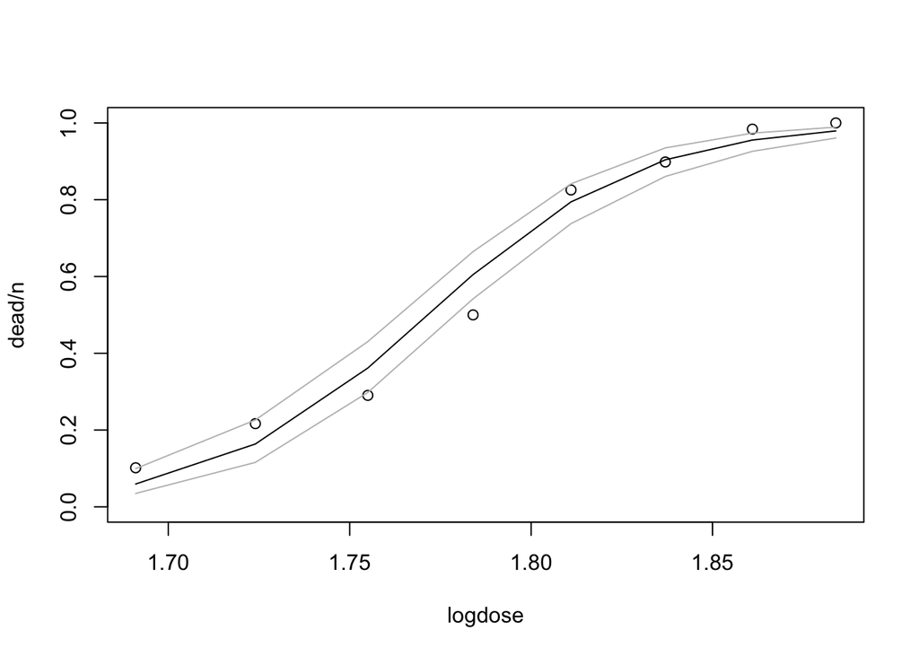

```r
## Sample proportions dead, fitted values for the model,
## 95% pointiwise CI for true probabilities
logdose<-beetles2$logdose
dead<-beetles2$dead
n<-beetles2$n
plot(logdose, dead/n, ylim=c(0,1))

lines(logdose, fitted(fit2))

pred<-predict(fit2, se.fit=TRUE)
U<- pred$fit + 1.96*pred$se.fit
L<- pred$fit - 1.96*pred$se.fit
lines(logdose, exp(U)/(1+exp(U)), col="grey")
lines(logdose, exp(L)/(1+exp(L)), col="grey")
```

**Prediction**

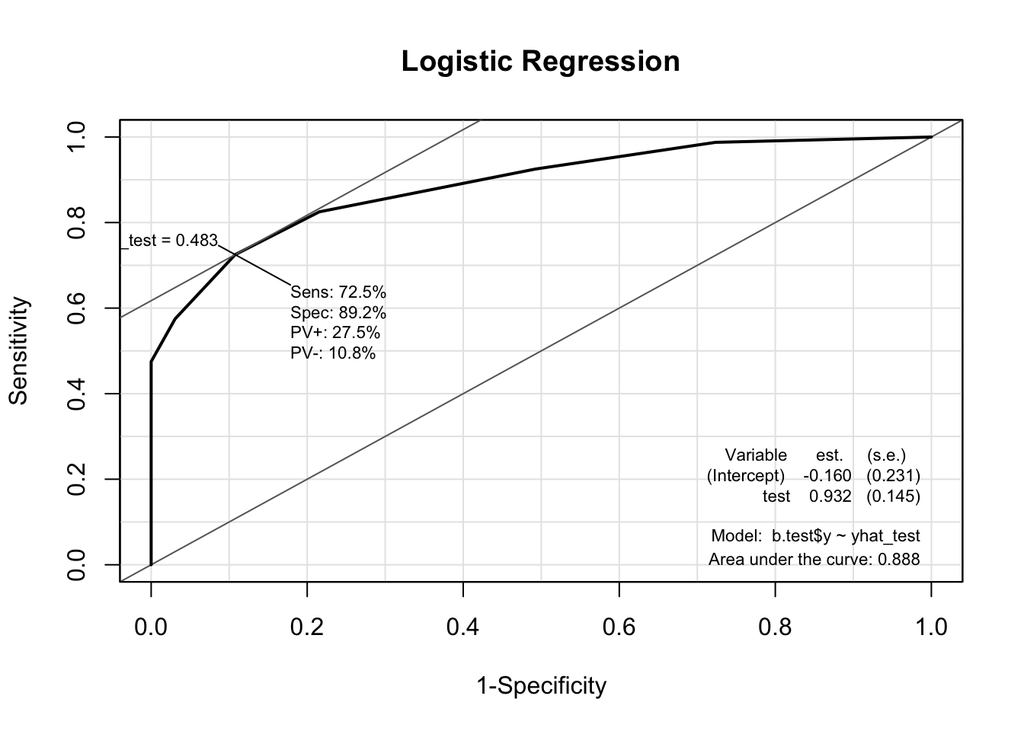

```r
set.seed(12345)
idx<-sample(1:nrow(beetles),size=nrow(beetles)*0.7)
b.train<-beetles[idx,]
b.test<-beetles[-idx,]

fit<-glm(y~x, data=b.train, family=binomial(link=logit))

yhat_test <- predict(fit, b.test)

library("Epi")
ROC(test = yhat_test, stat = b.test$y, plot="ROC", AUC=T, main="Logistic Regression")
```

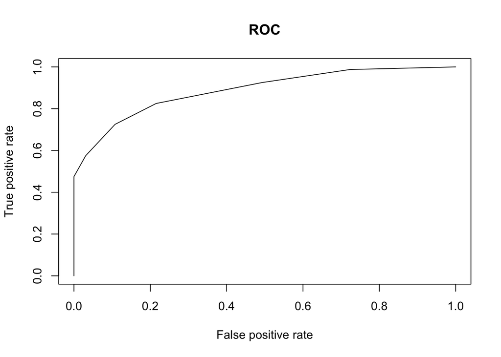

```r
library("ROCR") # to construct ROC curve
pred <- prediction(yhat_test,b.test$y)
perf <- performance(pred, "tpr", "fpr")
plot(perf, main="ROC")
```

```r
performance(pred,"auc")@y.values[[1]]
```

```
## [1] 0.8877885
```

### Extension to Logistic regression

**Polychotomous Logistic regression**

In some cases, we have a categorical outcome variable with more than two categories. Often we might have a single control group to be compared with multiple case groups or a single case group to be compared with multiple control groups.

**Example 13.46** Breast cancers are commonly typed using a biochemical assay to determine estrogen receptor (ER) and progesterone receptor (PR) status. Tumors can be jointly classified as having ER positive (ER+) vs. ER negative (ER-) status and PR positive (PR+) vs. PR negative (PR-) status. This distinction is important because different treatments are used according to ER/PR status. A study was performed within the NHS to determine risk factor profiles for specific types of breast cancer according to ER/PR status. There were 2096 incident cases of breast cancer from 1980−2000, of which 1281 were ER+/PR+, 417 were ER-/PR-, 318 were ER+/PR-, and 80 were ER-/PR+. There was a common control group for all types of breast cancers. How should the data be analyzed?

$$P(\text{ k th outcome category}) = \frac{\exp(\alpha_k + \sum_{j=1}^p \beta_{kj}x_j)}{1 + \sum_{q=1}^Q \exp(\alpha_q + \sum_{j=1}^p \beta_{qj}x_j) }$$
$$\Rightarrow
\log \frac{P(\text{ k th outcome category})}{P(\text{ 1 st outcome category})}
= \alpha_k + \sum_{j=1}^p \beta_{kj}x_j$$

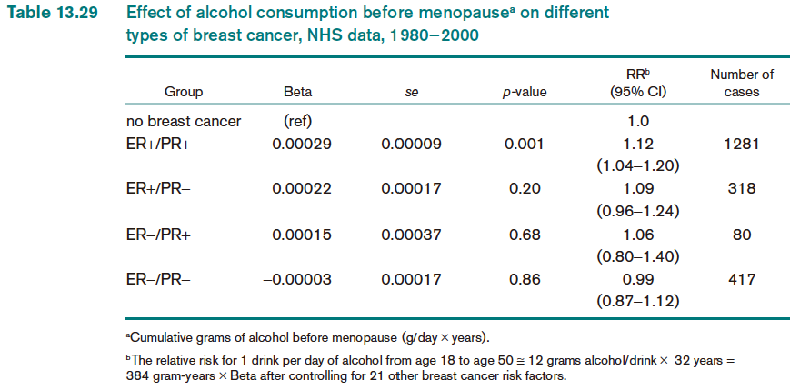

The results for alcohol consumption before menopause (adjusted for the other 21 variables in the model).

We see that there is a significant effect of alcohol for $ER+/PR+$ breast cancer but not for any other type of breast cancer.

**Oridinal Logistic regression**

**Example 13.48** In the data set TENNIS1.DAT (on the Companion Website) we have data from an observational study among about 400 members of several tennis clubs in the Boston area. The objective of the study was to examine risk factors for tennis elbow. Subjects were asked how many current or previous episodes of tennis elbow they had. The distribution ranged from 0 to 8 and was very skewed. Hence, we elected to categorize the number of episodes into 3 categories (0/1/2+). We could treat these 3 categories as nominal categorical data and use PLR, but this type of analysis would lose the ordering of the categories in the above scale. Instead, we used a technique called ordinal logistic regression to relate the number of episodes of tennis elbow to age, sex, and the material of the racquet.

Suppose an outcome variable $y$ has $c$ ordered categories, $y\in \{1,...,c\}$. Ordinal logistic regression model is given by
$$\log[P(y\leq j)/(1-P(y\leq j))] = \alpha_j + \beta_1 x_1 + ... + \beta_p x_p, j=1,...,c-1$$

Then,
$$e^{\beta_q} = (\text{ odds that } y\leq j |x_q=x)/(\text{ odds that } y\leq j |x_q=x-1)$$

```r
load("Data/TENNIS1.DAT.Rdata")
head(tennis1)
```

```
##   Id Age Sex Num_epis Typ_last Wgt_Last Mat_last Str_last Typ_curr
## 1  1  53   1        3        1        3        5        2        1
## 2  2  57   1        3        1        3        1        1        2
## 3  3  43   1        1        1        2        2        1        1
## 4  4  35   2        2        1        3        3        2        1
## 5  5  43   1        2        1        3        2        2        1
## 6  6  31   1        1        1        3        4        2        1
##   Wgt_curr Mat_curr Str_curr
## 1        3        5        2
## 2        2        2        1
## 3        2        4        1
## 4        3        3        2
## 5        3        2        2
## 6        3        4        2
```

```r
table(tennis1$Num_epis)
```

```
##
##   0   1   2   3   4   5   6   7   8   9
## 171 152  59  24   8   4   1   1  22   2
```

```r
tennis1$y[tennis1$Num_epis==0]<-0
tennis1$y[tennis1$Num_epis==1]<-1
tennis1$y[tennis1$Num_epis>1]<-2

idx<-tennis1[,9]==9|tennis1[,10]==9|tennis1[,11]==9|tennis1[,12]==9|tennis1[,2]==99|tennis1[,4]==9

tennis2<-tennis1[!idx,]
table(tennis2$Mat_curr)
```

```
##
##   1   2   3   4   5   6   7
## 107 174  67  60  17   1   6
```

```r
tennis2$Mat[tennis2$Mat_curr==1]<-1
tennis2$Mat[tennis2$Mat_curr>=2 & tennis2$Mat_curr<=3]<-2
tennis2$Mat[tennis2$Mat_curr>=4 ]<-3
library(VGAM)
fit<-vglm(y~Age+as.factor(Sex)+as.factor(Mat), family=cumulative(parallel=TRUE), data=tennis2)
summary(fit)
```

```
##
## Call:
## vglm(formula = y ~ Age + as.factor(Sex) + as.factor(Mat), family = cumulative(parallel = TRUE),
##     data = tennis2)
##
##
## Pearson residuals:
##                   Min      1Q  Median     3Q   Max
## logit(P[Y<=1]) -2.040 -0.8964 -0.3411 1.0159 2.738
## logit(P[Y<=2]) -3.607 -0.9349  0.3166 0.7749 1.336
##
## Coefficients:
##                 Estimate Std. Error z value Pr(>|z|)
## (Intercept):1    2.37334    0.50267   4.721 2.34e-06 ***
## (Intercept):2    3.94601    0.52603   7.501 6.31e-14 ***
## Age             -0.05628    0.01078  -5.222 1.77e-07 ***
## as.factor(Sex)2 -0.43904    0.18798  -2.335  0.01952 *
## as.factor(Mat)2 -0.23789    0.22142  -1.074  0.28265
## as.factor(Mat)3 -0.82074    0.27725  -2.960  0.00307 **
## ---
## Signif. codes:  0 '***' 0.001 '**' 0.01 '*' 0.05 '.' 0.1 ' ' 1
##
## Number of linear predictors:  2
##
## Names of linear predictors: logit(P[Y<=1]), logit(P[Y<=2])
##
## Residual deviance: 899.7492 on 858 degrees of freedom
##
## Log-likelihood: -449.8746 on 858 degrees of freedom
##
## Number of iterations: 5
##
## No Hauck-Donner effect found in any of the estimates
##
## Exponentiated coefficients:
##             Age as.factor(Sex)2 as.factor(Mat)2 as.factor(Mat)3
##       0.9452785       0.6446570       0.7882903       0.4401053
```

```r
head(fitted(fit))
```

```
##           0         1         2
## 1 0.1930960 0.3425087 0.4643952
## 2 0.2549722 0.3675836 0.3774443
## 3 0.2958247 0.3735630 0.3306122
## 4 0.4321121 0.3536284 0.2142596
## 5 0.4293735 0.3544807 0.2161458
## 6 0.4521588 0.3469487 0.2008925
```

## Meta Analysis

Often more than one investigation is performed to study a particular research question, often by different research groups.

How to combine those informations?

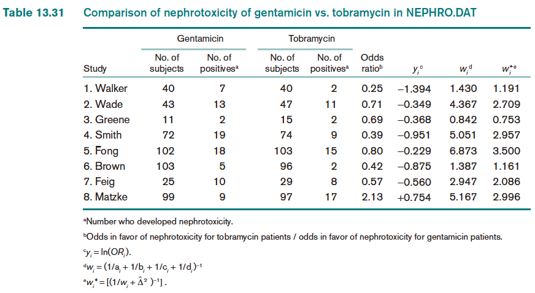

Suppose there is an underlying log odds ratio $\theta_i$ for the $i$th study, which is estimated by $y_i = \log \hat OR_i$.

- Within-study variation of $y_i$ : $s_i^2= 1/w_i = 1/a_i + 1/b_i +1/c_i +1/d_i$.
- Between-study variation: $\theta_i = \mu + \delta_i$ with $Var(\delta_i) = \Delta^2$.

$$\hat \mu = \sum_i w_i^*y_i / \sum_i w_i^*$$
where $w_i^* = (s_i^2 + \hat \Delta^2)^{-1}$: the weight for the $i$th study is inversely proportional to the total variance for that study.

$$SE(\hat \mu) = (1/\sum_i w_i^*)^{1/2}$$

```r
library(metafor)
load("Data/NEPHRO.DAT.RData")
head(nephro)
```

```
##     Name Id Endpnt Antibio Samp_sz Side_eff
## 1  BODEY  3      2       2      11        0
## 2  BODEY  3      2       4      11        0
## 3  BODEY  3      2       5      11        2
## 4  KLAST  4      2       2      21        4
## 5  KLAST  4      2       4      25        4
## 6 WALKER  6      2       2      40        7
```

```r
nephro2<-cbind(
nephro[nephro$Name%in%c("WALKER","WADE","GREENE","SMITH80","FONG","BROWN",
                        "FEIG","MATZKE")
                      &nephro$Antibio==2,c(1,5,6)],
nephro[nephro$Name%in%c("WALKER","WADE","GREENE","SMITH80","FONG","BROWN",
                        "FEIG","MATZKE")
       &nephro$Antibio==5,c(5,6)])

names(nephro2)<-c("Name","Gentamicin_n","Gentamicin_p","Tobramycin_n","Tobramycin_p")
nephro2$ai<-nephro2[,3];
nephro2$bi<-nephro2[,2]-nephro2[,3];
nephro2$ci<-nephro2[,5]
nephro2$di<-nephro2[,4]-nephro2[,5]


meta.dat<-escalc(measure = "OR", ai = ci, bi = di, ci = ai,
                 di = bi, data = nephro2, append = TRUE)
meta.dat
```

```
##       Name Gentamicin_n Gentamicin_p Tobramycin_n Tobramycin_p ai bi ci di
## 6   WALKER           40            7           40            2  7 33  2 38
## 23    WADE           43           13           47           11 13 30 11 36
## 28  GREENE           11            2           15            2  2  9  2 13
## 49 SMITH80           72           19           74            9 19 53  9 65
## 51    FONG          102           18          103           15 18 84 15 88
## 59   BROWN          103            5           96            2  5 98  2 94
## 61    FEIG           25           10           29            8 10 15  8 21
## 69  MATZKE           99            9           97           17  9 90 17 80
##         yi     vi
## 6  -1.3938 0.6995
## 23 -0.3494 0.2289
## 28 -0.3677 1.1880
## 49 -0.9513 0.1980
## 51 -0.2288 0.1455
## 59 -0.8746 0.7208
## 61 -0.5596 0.3393
## 69  0.7538 0.1935
```

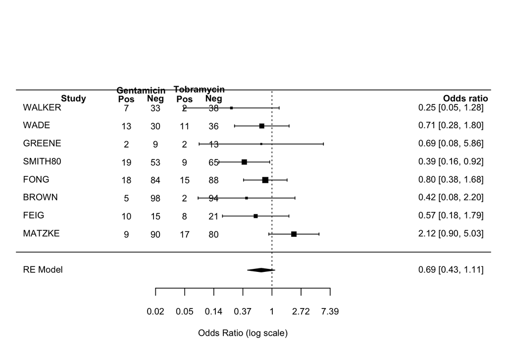

```r
res<-rma(yi,vi, data=meta.dat,method="DL")


forest(res, slab = paste(meta.dat$Name),
atransf = exp,
ilab = cbind(meta.dat$ai, meta.dat$bi, meta.dat$ci, meta.dat$di),
ilab.xpos = c(-5,-4,-3,-2), cex = 0.75)

op <- par(cex = 0.75, font = 2)
text(c(-5, -4, -3, -2), 8.5, c("Pos", "Neg", "Pos", "Neg"))
text(c(-4.5, -2.5), 9, c("Gentamicin", "Tobramycin"))
text(-7.5, 8.5, "Study", pos = 4)
text(9, 8.5, "Odds ratio [95% CI]", pos = 2)
```

```r
par(op)
```

- Test for homogeneiety of Study-specific ORs in Meta Analysis

$$H_0: \theta_1 = ... = \theta_k$$
$$Q_w = \sum_{i=1}^k w_i (y_i - \bar y_w)^2 \sim \chi^2_{k-1} \text{ under } H_0$$

```r
res
```

```
##
## Random-Effects Model (k = 8; tau^2 estimator: DL)
##
## tau^2 (estimated amount of total heterogeneity): 0.1402 (SE = 0.2390)
## tau (square root of estimated tau^2 value):      0.3745
## I^2 (total heterogeneity / total variability):   31.88%
## H^2 (total variability / sampling variability):  1.47
##
## Test for Heterogeneity:
## Q(df = 7) = 10.2761, p-val = 0.1735
##
## Model Results:
##
## estimate      se     zval    pval    ci.lb   ci.ub
##  -0.3701  0.2401  -1.5415  0.1232  -0.8406  0.1005
##
## ---
## Signif. codes:  0 '***' 0.001 '**' 0.01 '*' 0.05 '.' 0.1 ' ' 1
```